# TRABAJO INDIVIDUAL FEADE-AEDM

## 4. Determinación del número óptimo de conglomerados o clases

**A. Realiza un análisis jerárquico de clasificación no supervisado y encuentra la estrategia de enlace óptima. Obtén y comenta el correspondiente dendrograma. Incluye distintas estrategias de enlace, la comparación y la justificación de la elección.**

Creamos la matriz de proximidad-distancia.

```r
dist.autismo <- dist(autismo.comp)
```

**Vamos haciendo los diferentes metodos de enlace.**

Método de enlace simple (vecino mas cercano)

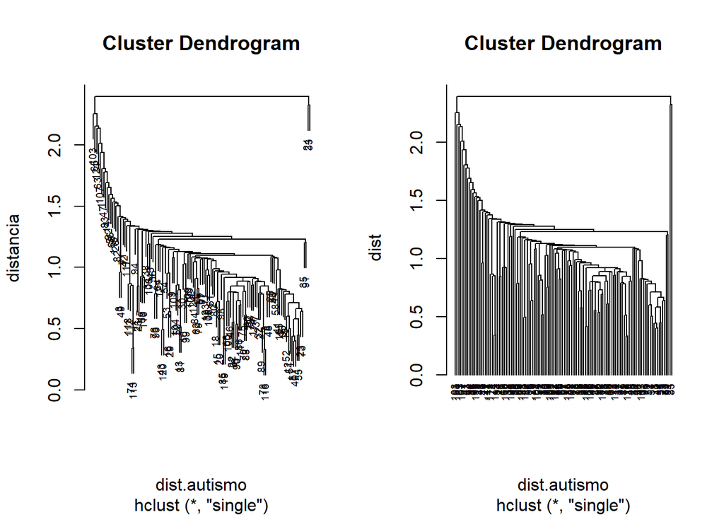

```r
autismo.single <-  hclust(dist.autismo, method = "single")
par(mfrow=c(1,2))
plot(autismo.single, ylab = "distancia", cex=0.6)
plot(autismo.single, ylab ="dist", hang=-1, cex=0.6)
```

Método de enlace completo (vecino mas lejano)

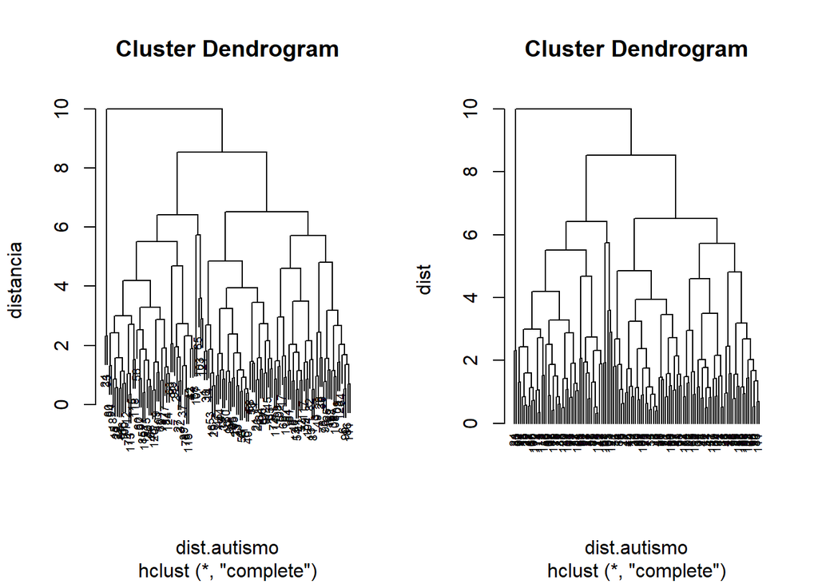

```r
autismo.complete <- hclust(dist.autismo, method = "complete")
par(mfrow=c(1,2))
plot(autismo.complete, ylab = "distancia", cex=0.6)
plot(autismo.complete, ylab ="dist", hang=-1, cex=0.6)
```

Método del centroide

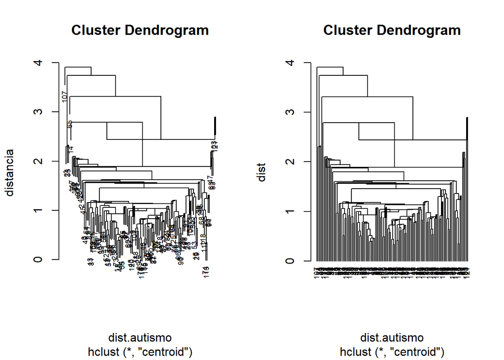

```r
autismo.centroid <- hclust(dist.autismo, method = "centroid")
par(mfrow=c(1,2))
plot(autismo.centroid, ylab = "distancia", cex=0.6)
plot(autismo.centroid, ylab ="dist", hang=-1, cex=0.6)
```

Método de ward

```r
autismo.ward <- hclust(dist.autismo, method = "ward")
```

```
## The "ward" method has been renamed to "ward.D"; note new "ward.D2"
```

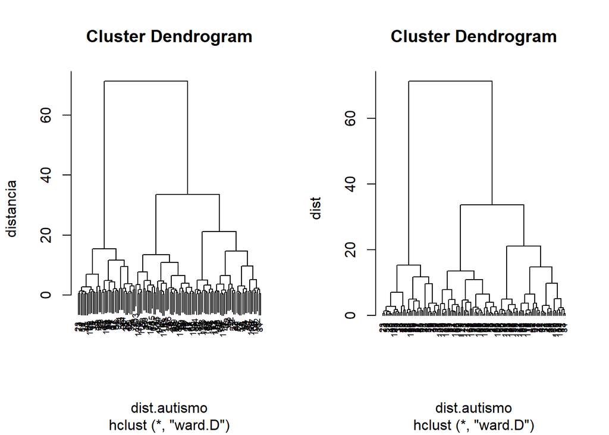

```r
par(mfrow=c(1,2))
plot(autismo.ward, ylab = "distancia", cex=0.6)
plot(autismo.ward, ylab ="dist", hang=-1, cex=0.6)
```

Método promedio

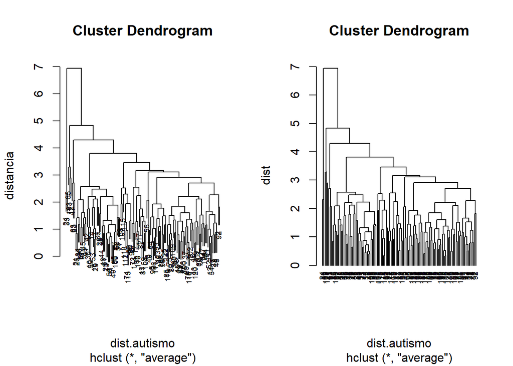

```r
autismo.average <- hclust(dist.autismo, method = "average")
par(mfrow=c(1,2))
plot(autismo.average, ylab = "distancia", cex=0.6)
plot(autismo.average, ylab ="dist", hang=-1, cex=0.6)
```

Evaluacion cofonetico del mejor metodo de enlace.

```r
sing=cor(dist.autismo,cophenetic(autismo.single))
comp=cor(dist.autismo,cophenetic(autismo.complete))
cent=cor(dist.autismo,cophenetic(autismo.centroid))
avg=cor(dist.autismo,cophenetic(autismo.average))
ward=cor(dist.autismo,cophenetic(autismo.ward))
best=data.frame(sing,comp,cent,avg,ward)
round(best,2)
```

| sing | comp | cent | avg | ward |
| --- | --- | --- | --- | --- |
| 0.65 | 0.56 | 0.64 | 0.71 | 0.46 |

El más adecuado será el que mayor valor tenga (en este caso, metodo promedio). No obstante, los valores son similares entre si por lo que recurrimos a tanglegrama para enfrentar dendogramas que puedan ser a priori adecuados.

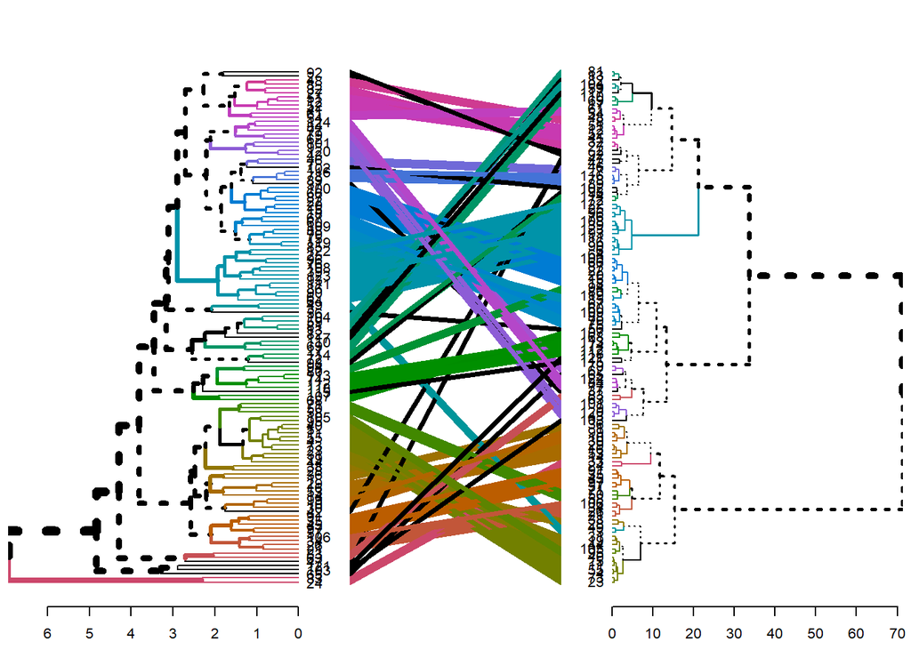

```r
library(dendextend)
tanglegram(autismo.average,autismo.ward, highlight_distinct_edges = TRUE,
           common_subtrees_color_branches = TRUE)
```

*Interpretación*

Comparamos dendogramas con el tanglegrama, los enfrentamos entre sí. En nuestro caso, el que mejor coeficiente cofonetico tiene es el metodo de enlace promedio, aunque visualmente pueda parecer que posee una mejor representación el metodo de ward ya que se aprecian las ramas más diferenciadas. En un tanglegram, las líneas más gruesas sugieren una mayor similitud entre las estructuras de agrupamiento, mientras que las líneas más delgadas o la ausencia de líneas indican diferencias en las agrupaciones. Por lo tanto, aunque ambos metodos me hacen la partición de clusters a la misma distancia, las lineas del metodo de enlace promedio son mas gruesas entre clusters por lo que habra mas similitud entre individuos, dentro del mismo cluster.

TENIENDO ESTO EN CUENTA Y QUE EL COEFICIENTE COFONETICO ES MAYOR -> ELEGIMOS METODO PROMEDIO DE ENLACE.

**B. Determina el número de conglomerados adecuado.**

```r
autismo.hcpc <- HCPC(as.data.frame(autismo.comp), nb.clust = -1, method = "average")
```

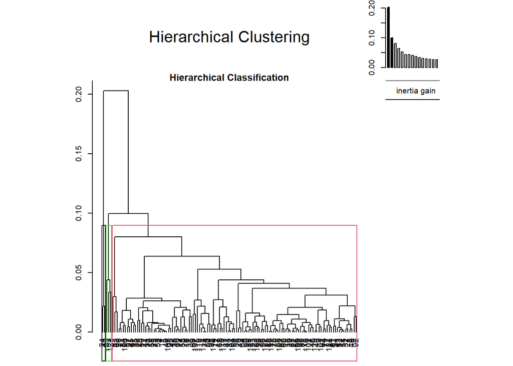

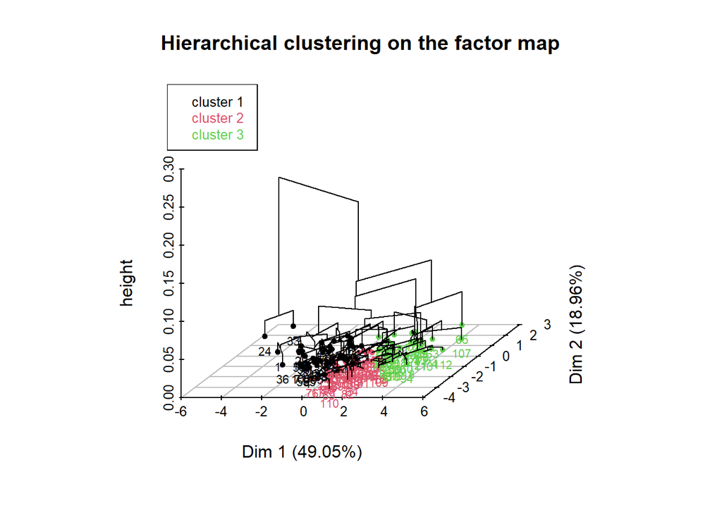

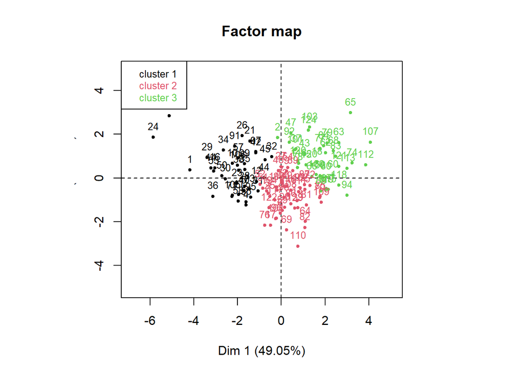

Las componentes han de ser independientes de ahi lo de incluir el pca antes. Las componentes principales son ortogonales entre sí, lo que significa que son linealmente independientes y no están correlacionadas. Podemos observar, que individuos son incluidos en cada cluster y el respectivo dendograma sobre la sobre la nube de puntos. Extraemos un k de 3, es decir, 3 congloromedas adecuados. Es valor será el que incluiremos en el algoritmo k-means -> CLUSTERING NO JERÁRQUICO

**C. Obtén el número de individuos y de qué grupo están incluidos en cada uno de los conglomerados obtenidos.**

A continuación, vamos a obtener a visualizar la posicion de fila de cada observación de datos.autismo, es decir, los individuos que pertencen a cada cluster y seguidamente a que grupo pertenecen cada unos de ellos.

```r
autismo.clust <- lapply(1:3, function(nc) datos.autismo$factor[autismo.hcpc$data.clust$clust==nc])
autismo.clust
```

```
## [[1]]
##  [1] Control Control Control Control Control Control Control Control Control
## [10] Control Control Control Control Control Control Control Control Control
## [19] Control Control Control Control Control Control Control Control Control
## [28] Control Control Control Control Autism  Autism  Autism  Autism  Autism
## [37] Autism  Autism  Autism
## Levels: Autism Control
##
## [[2]]
##  [1] Control Control Control Control Control Control Control Control Control
## [10] Control Control Control Control Control Control Control Control Control
## [19] Control Control Autism  Autism  Autism  Autism  Autism  Autism  Autism
## [28] Autism  Autism  Autism  Autism  Autism  Autism  Autism  Autism  Autism
## [37] Autism  Autism  Autism  Autism  Autism  Autism  Autism  Autism  Autism
## [46] Autism  Autism
## Levels: Autism Control
##
## [[3]]
##  [1] Control Control Control Control Control Control Control Control Autism
## [10] Autism  Autism  Autism  Autism  Autism  Autism  Autism  Autism  Autism
## [19] Autism  Autism  Autism  Autism  Autism  Autism  Autism  Autism  Autism
## [28] Autism  Autism  Autism  Autism  Autism  Autism  Autism  Autism  Autism
## [37] Autism  Autism
## Levels: Autism Control
```

```r
autismo.clust2 <- lapply(1:3, function(nc) row.names(datos.autismo)[autismo.hcpc$data.clust$clust==nc])
autismo.clust2
```

```
## [[1]]
##  [1] "1"   "4"   "5"   "10"  "11"  "12"  "14"  "16"  "21"  "23"  "24"  "26"
## [13] "28"  "29"  "30"  "31"  "32"  "33"  "34"  "35"  "36"  "38"  "40"  "42"
## [25] "44"  "45"  "50"  "53"  "55"  "57"  "58"  "71"  "73"  "91"  "95"  "97"
## [37] "99"  "105" "106"
##
## [[2]]
##  [1] "3"   "6"   "7"   "8"   "9"   "13"  "17"  "19"  "22"  "25"  "27"  "39"
## [13] "41"  "46"  "48"  "49"  "51"  "52"  "54"  "59"  "61"  "64"  "69"  "70"
## [25] "72"  "75"  "76"  "81"  "82"  "85"  "86"  "87"  "89"  "90"  "93"  "96"
## [37] "98"  "102" "104" "108" "109" "110" "111" "114" "117" "122" "123"
##
## [[3]]
##  [1] "2"   "15"  "18"  "20"  "37"  "43"  "47"  "56"  "60"  "62"  "63"  "65"
## [13] "66"  "67"  "68"  "74"  "77"  "78"  "79"  "80"  "83"  "84"  "88"  "92"
## [25] "94"  "100" "101" "103" "107" "112" "113" "115" "116" "118" "119" "120"
## [37] "121" "124"
```

Extraemos que, el primer cluster recoge mayoritariamente a organismos control, el segundo está formado por mas o menos la misma proporcion de control y de autistas El tercero, predominan autistas. Esto concuerda con el solapamiento visto en el PCA respecto a los grupos Control y Autismo.

```r
asignacion_clusters_hcpc <- autismo.hcpc$data.clust$clust
table(datos.autismo$factor, asignacion_clusters_hcpc)
```

```
##          asignacion_clusters_hcpc
##            1  2  3
##   Autism   8 27 30
##   Control 31 20  8
```

Finalmente, aqui se ve una forma mas resumida como se distribuyen los individuos en cada cluster y el grupo al que pertenecen.

A continuación, veremos un heatmap de expresion genética donde relacionaremos individuos y genes.

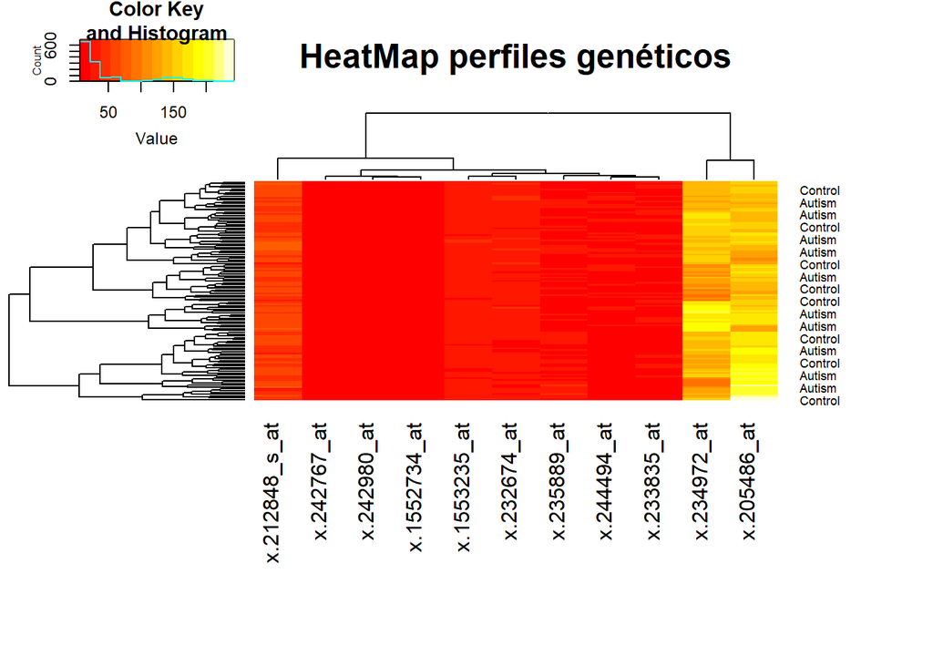

```r
library(gplots)
library(RColorBrewer)
heatmap.2(as.matrix(datos.autismo[,1:11]),
          scale="none",
          density.info="histogram",
          trace= "none",
          labRow = datos.autismo$factor,
          margins=c(12,7), main = "HeatMap perfiles genéticos",
          cex.axis=1.0,
          cex.main=.6)
```

*Interpretación*

Vemos dendogramas de individuos (izquierda) y de genes(arriba) enfrentados con sus respectivos valores de expresión representados por diferentes colores en una matriz de expresión que a su derecha viene indicado el grupo al que pertenece cada individuo. Podemos extraer poca información de esta representación ya que no hay una gran diferencia de expresión entre grupos en los genes. Si podemos destacar que al igual que podemos ver en los valores del data frame, los genes 234972_at y 205486_at comparten valores similares de expresión (altos valores amarillo), la variable 212848_s_at presenta valores mas bajos (naranja) pero son mas altos que los valores del resto de variables que mantienen unos valores similares (rojo).

## 5. Realiza un análisis clúster no jerárquico de los individuos. Interpreta los resultados.

Cluster no jerarquico: k-means con k=3

```r
set.seed(123); km <- kmeans(autismo.comp,3)
km
```

```
## K-means clustering with 3 clusters of sizes 39, 38, 47
##
## Cluster means:
##        Dim.1      Dim.2       Dim.3       Dim.4
## 1 -2.1505212  0.2781977 -0.13834938 -0.03594206
## 2  1.8448587  0.8203509  0.03405317 -0.09746331
## 3  0.2928872 -0.8941074  0.08726820  0.10862439
##
## Clustering vector:
##   1   2   3   4   5   6   7   8   9  10  11  12  13  14  15  16  17  18  19  20
##   1   2   3   1   1   3   3   3   3   1   1   1   3   1   2   1   3   2   3   2
##  21  22  23  24  25  26  27  28  29  30  31  32  33  34  35  36  37  38  39  40
##   1   3   1   1   3   1   3   1   1   1   1   1   1   1   1   1   2   1   3   1
##  41  42  43  44  45  46  47  48  49  50  51  52  53  54  55  56  57  58  59  60
##   3   1   2   1   1   3   2   3   3   1   3   3   1   3   1   2   1   1   3   2
##  61  62  63  64  65  66  67  68  69  70  71  72  73  74  75  76  77  78  79  80
##   3   2   2   3   2   2   2   2   3   3   1   3   1   2   3   3   2   2   2   2
##  81  82  83  84  85  86  87  88  89  90  91  92  93  94  95  96  97  98  99 100
##   3   3   2   2   3   3   3   2   3   3   1   2   3   2   1   3   1   3   1   2
## 101 102 103 104 105 106 107 108 109 110 111 112 113 114 115 116 117 118 119 120
##   2   3   2   3   1   1   2   3   3   3   3   2   2   3   2   2   3   2   2   2
## 121 122 123 124
##   2   3   3   2
##
## Within cluster sum of squares by cluster:
## [1] 150.5212 158.0936 163.4409
##  (between_SS / total_SS =  44.7 %)
##
## Available components:
##
## [1] "cluster"      "centers"      "totss"        "withinss"     "tot.withinss"
## [6] "betweenss"    "size"         "iter"         "ifault"
```

*Interpretación*

Las medias de los conglomerados proporcionan información sobre los valores medios de cada dimensión dentro de cada conglomerado. Los valores WCSS dan una idea del grado de agrupación de los puntos dentro de cada grupo. El porcentaje de variabilidad explicada indica en qué medida los conglomerados captan la variabilidad global de los datos (44.7%, es un valor relativamente bajo). En general, un WCSS más bajo y un mayor porcentaje de variabilidad explicada sugieren un mejor ajuste de los conglomerados a los datos.

```r
autismo.km <- lapply(1:3, function(nc) row.names(datos.autismo)[km$cluster==nc])
autismo.km
```

```
## [[1]]
##  [1] "1"   "4"   "5"   "10"  "11"  "12"  "14"  "16"  "21"  "23"  "24"  "26"
## [13] "28"  "29"  "30"  "31"  "32"  "33"  "34"  "35"  "36"  "38"  "40"  "42"
## [25] "44"  "45"  "50"  "53"  "55"  "57"  "58"  "71"  "73"  "91"  "95"  "97"
## [37] "99"  "105" "106"
##
## [[2]]
##  [1] "2"   "15"  "18"  "20"  "37"  "43"  "47"  "56"  "60"  "62"  "63"  "65"
## [13] "66"  "67"  "68"  "74"  "77"  "78"  "79"  "80"  "83"  "84"  "88"  "92"
## [25] "94"  "100" "101" "103" "107" "112" "113" "115" "116" "118" "119" "120"
## [37] "121" "124"
##
## [[3]]
##  [1] "3"   "6"   "7"   "8"   "9"   "13"  "17"  "19"  "22"  "25"  "27"  "39"
## [13] "41"  "46"  "48"  "49"  "51"  "52"  "54"  "59"  "61"  "64"  "69"  "70"
## [25] "72"  "75"  "76"  "81"  "82"  "85"  "86"  "87"  "89"  "90"  "93"  "96"
## [37] "98"  "102" "104" "108" "109" "110" "111" "114" "117" "122" "123"
```

```r
autismo.km2 <- lapply(1:3, function(nc) datos.autismo$factor[km$cluster==nc])
autismo.km2
```

```
## [[1]]
##  [1] Control Control Control Control Control Control Control Control Control
## [10] Control Control Control Control Control Control Control Control Control
## [19] Control Control Control Control Control Control Control Control Control
## [28] Control Control Control Control Autism  Autism  Autism  Autism  Autism
## [37] Autism  Autism  Autism
## Levels: Autism Control
##
## [[2]]
##  [1] Control Control Control Control Control Control Control Control Autism
## [10] Autism  Autism  Autism  Autism  Autism  Autism  Autism  Autism  Autism
## [19] Autism  Autism  Autism  Autism  Autism  Autism  Autism  Autism  Autism
## [28] Autism  Autism  Autism  Autism  Autism  Autism  Autism  Autism  Autism
## [37] Autism  Autism
## Levels: Autism Control
##
## [[3]]
##  [1] Control Control Control Control Control Control Control Control Control
## [10] Control Control Control Control Control Control Control Control Control
## [19] Control Control Autism  Autism  Autism  Autism  Autism  Autism  Autism
## [28] Autism  Autism  Autism  Autism  Autism  Autism  Autism  Autism  Autism
## [37] Autism  Autism  Autism  Autism  Autism  Autism  Autism  Autism  Autism
## [46] Autism  Autism
## Levels: Autism Control
```

Vemos a que cluster pertenece cada observacion y de que grupo(clase) es y se organizan de forma similar a como ocurría en el clustering jerarquico.

VISUALIZACIÓN DE LA NUBE DE PUNTOS CLUSTER K-MEANS.

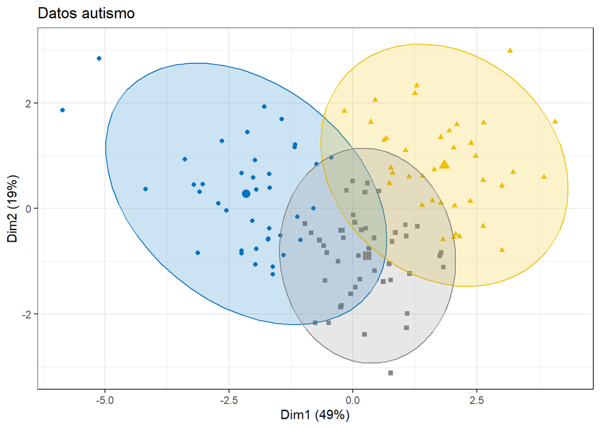

```r
fviz_cluster(object = km, data = autismo.comp,
             ellipse.type = "norm", geom = "point", main = "Datos autismo",
             stand = FALSE, palette = "jco") +
  theme_bw() + theme(legend.position = "none")
```

Debido a que el algoritmo de K-means no evalúa todas las posibles distribuciones de las observaciones sino solo parte de ellas, los resultados obtenidos dependen de la asignación aleatoria inicial (paso 1). Por esta razón, es importante ejecutar el algoritmo varias veces, cada una con una asignación aleatoria inicial distinta, y seleccionar aquella que haya conseguido un menor valor de varianza total (WCSS por cluster).

```r
set.seed(1234); km.changeseed1 <- kmeans(autismo.comp,3)
km.changeseed1$withinss
```

```
## [1] 153.57268 248.79372  96.15844
```

```r
set.seed(12345); km.changeseed2 <- kmeans(autismo.comp,3)
km.changeseed2$withinss
```

```
## [1] 128.4403 169.6240 174.6230
```

```r
set.seed(456); km.changeseed3 <- kmeans(autismo.comp,3)
km.changeseed3$withinss
```

```
## [1] 135.0007 180.1747 158.6903
```

```r
set.seed(9876); km.changeseed4 <- kmeans(autismo.comp,3)
km.changeseed4$withinss
```

```
## [1] 158.0936 150.5212 163.4409
```

Además, cambiamos también el número de iteraciones mínimas para aumentar la estabilidad del resultado junto con los cambios de semilla de aleatorizacón.

```r
km.changeiter <- kmeans(autismo.comp, centers=3, iter.max=100, nstart=25)
km.changeiter$withinss
```

```
## [1] 150.5212 163.4409 158.0936
```

```r
km.changeiter2 <- kmeans(autismo.comp, centers=3, iter.max=1000, nstart=150)
km.changeiter2
```

```
## K-means clustering with 3 clusters of sizes 39, 47, 38
##
## Cluster means:
##        Dim.1      Dim.2       Dim.3       Dim.4
## 1 -2.1505212  0.2781977 -0.13834938 -0.03594206
## 2  0.2928872 -0.8941074  0.08726820  0.10862439
## 3  1.8448587  0.8203509  0.03405317 -0.09746331
##
## Clustering vector:
##   1   2   3   4   5   6   7   8   9  10  11  12  13  14  15  16  17  18  19  20
##   1   3   2   1   1   2   2   2   2   1   1   1   2   1   3   1   2   3   2   3
##  21  22  23  24  25  26  27  28  29  30  31  32  33  34  35  36  37  38  39  40
##   1   2   1   1   2   1   2   1   1   1   1   1   1   1   1   1   3   1   2   1
##  41  42  43  44  45  46  47  48  49  50  51  52  53  54  55  56  57  58  59  60
##   2   1   3   1   1   2   3   2   2   1   2   2   1   2   1   3   1   1   2   3
##  61  62  63  64  65  66  67  68  69  70  71  72  73  74  75  76  77  78  79  80
##   2   3   3   2   3   3   3   3   2   2   1   2   1   3   2   2   3   3   3   3
##  81  82  83  84  85  86  87  88  89  90  91  92  93  94  95  96  97  98  99 100
##   2   2   3   3   2   2   2   3   2   2   1   3   2   3   1   2   1   2   1   3
## 101 102 103 104 105 106 107 108 109 110 111 112 113 114 115 116 117 118 119 120
##   3   2   3   2   1   1   3   2   2   2   2   3   3   2   3   3   2   3   3   3
## 121 122 123 124
##   3   2   2   3
##
## Within cluster sum of squares by cluster:
## [1] 150.5212 163.4409 158.0936
##  (between_SS / total_SS =  44.7 %)
##
## Available components:
##
## [1] "cluster"      "centers"      "totss"        "withinss"     "tot.withinss"
## [6] "betweenss"    "size"         "iter"         "ifault"
```

```r
km.changeiter3 <- kmeans(autismo.comp, centers=3, iter.max=500, nstart=50)
km.changeiter3
```

```
## K-means clustering with 3 clusters of sizes 39, 38, 47
##
## Cluster means:
##        Dim.1      Dim.2       Dim.3       Dim.4
## 1 -2.1505212  0.2781977 -0.13834938 -0.03594206
## 2  1.8448587  0.8203509  0.03405317 -0.09746331
## 3  0.2928872 -0.8941074  0.08726820  0.10862439
##
## Clustering vector:
##   1   2   3   4   5   6   7   8   9  10  11  12  13  14  15  16  17  18  19  20
##   1   2   3   1   1   3   3   3   3   1   1   1   3   1   2   1   3   2   3   2
##  21  22  23  24  25  26  27  28  29  30  31  32  33  34  35  36  37  38  39  40
##   1   3   1   1   3   1   3   1   1   1   1   1   1   1   1   1   2   1   3   1
##  41  42  43  44  45  46  47  48  49  50  51  52  53  54  55  56  57  58  59  60
##   3   1   2   1   1   3   2   3   3   1   3   3   1   3   1   2   1   1   3   2
##  61  62  63  64  65  66  67  68  69  70  71  72  73  74  75  76  77  78  79  80
##   3   2   2   3   2   2   2   2   3   3   1   3   1   2   3   3   2   2   2   2
##  81  82  83  84  85  86  87  88  89  90  91  92  93  94  95  96  97  98  99 100
##   3   3   2   2   3   3   3   2   3   3   1   2   3   2   1   3   1   3   1   2
## 101 102 103 104 105 106 107 108 109 110 111 112 113 114 115 116 117 118 119 120
##   2   3   2   3   1   1   2   3   3   3   3   2   2   3   2   2   3   2   2   2
## 121 122 123 124
##   2   3   3   2
##
## Within cluster sum of squares by cluster:
## [1] 150.5212 158.0936 163.4409
##  (between_SS / total_SS =  44.7 %)
##
## Available components:
##
## [1] "cluster"      "centers"      "totss"        "withinss"     "tot.withinss"
## [6] "betweenss"    "size"         "iter"         "ifault"
```

En nuestro caso, cuando cambiamos la semilla de aleatorizacion y el número mínimo de iteraciones, no se aprecia un cambio significativo en la varianza total interna entre cluster ni en el porcentaje de variabilidad explicada total en el k-means.

**A. ¿Cuántos individuo y de qué grupo están incluidos en cada uno de los conglomerados? Compara estos resultados con los del apartado 4.c.**

```r
asignacion_clusters_hcpc <- autismo.hcpc$data.clust$clust
table(datos.autismo$factor, asignacion_clusters_hcpc)
```

```
##          asignacion_clusters_hcpc
##            1  2  3
##   Autism   8 27 30
##   Control 31 20  8
```

```r
asignacion_clusters_kmeans <- km$cluster
table(datos.autismo$factor, asignacion_clusters_kmeans)
```

```
##          asignacion_clusters_kmeans
##            1  2  3
##   Autism   8 30 27
##   Control 31  8 20
```

*Interpretación y comparación*

Cuando comparamos clustering jerarquico y no jerarquico, vemos que la distribucion y partición entre cluster es prácticamente igual, tanto entre clases como en número. Por tanto, viendo que ambos tipos de clustering dan un resultado similar y estable podríamos pensar que el número de clusters es adecuado.

Ejemplo cambio k=4

```r
set.seed(123);km.changek1 <- kmeans(autismo.comp, centers=4)
km.changek1
```

```
## K-means clustering with 4 clusters of sizes 33, 43, 27, 21
##
## Cluster means:
##        Dim.1      Dim.2       Dim.3       Dim.4
## 1 -0.8755772 -0.7008858 -0.88178937 -0.05417695
## 2  1.8141968  0.6084827 -0.03384982 -0.12609386
## 3  0.2741518 -0.7707881  0.94577386  0.16349442
## 4 -2.6913578  0.8464645  0.23898559  0.13312029
##
## Clustering vector:
##   1   2   3   4   5   6   7   8   9  10  11  12  13  14  15  16  17  18  19  20
##   4   2   1   1   1   1   3   3   1   4   1   1   3   4   2   4   3   2   1   2
##  21  22  23  24  25  26  27  28  29  30  31  32  33  34  35  36  37  38  39  40
##   4   2   4   4   1   4   3   1   4   4   1   3   4   4   1   4   2   1   1   1
##  41  42  43  44  45  46  47  48  49  50  51  52  53  54  55  56  57  58  59  60
##   3   4   2   1   1   3   2   3   1   4   1   1   4   3   1   2   4   1   3   2
##  61  62  63  64  65  66  67  68  69  70  71  72  73  74  75  76  77  78  79  80
##   3   2   2   3   2   2   2   2   3   2   1   3   1   2   2   1   2   2   2   2
##  81  82  83  84  85  86  87  88  89  90  91  92  93  94  95  96  97  98  99 100
##   3   3   2   2   2   3   3   2   2   1   4   3   1   2   1   1   4   3   4   2
## 101 102 103 104 105 106 107 108 109 110 111 112 113 114 115 116 117 118 119 120
##   2   3   2   3   1   4   2   1   2   3   3   2   2   3   2   2   3   2   2   2
## 121 122 123 124
##   2   1   1   2
##
## Within cluster sum of squares by cluster:
## [1]  88.74709 168.29832  76.40394  83.49609
##  (between_SS / total_SS =  51.2 %)
##
## Available components:
##
## [1] "cluster"      "centers"      "totss"        "withinss"     "tot.withinss"
## [6] "betweenss"    "size"         "iter"         "ifault"
```

```r
asignacion_clusters_kmeanschange1 <- km.changek1$cluster
table(datos.autismo$factor, asignacion_clusters_kmeanschange1)
```

```
##          asignacion_clusters_kmeanschange1
##            1  2  3  4
##   Autism  11 34 16  4
##   Control 22  9 11 17
```

Los métodos de clustering son capaces de encontrar agrupaciones en cualquier set de datos, independientemente de que realmente existan o no dichos grupos en la población de la que proceden las observaciones.

Además, aunque no sucede en nuestro caso, cada uno de los métodos de clustering podría dar lugar a resultados distintos.

Deberemos validar los clusters evaluando la veracidad de los grupos obtenidos.

A modo general, este proceso consta de tres partes: estudio de la tendencia de clustering, elección del número óptimo de clusters y estudio de la calidad/significancia de los clusters generados.

**Elección del número óptimo de clusters**

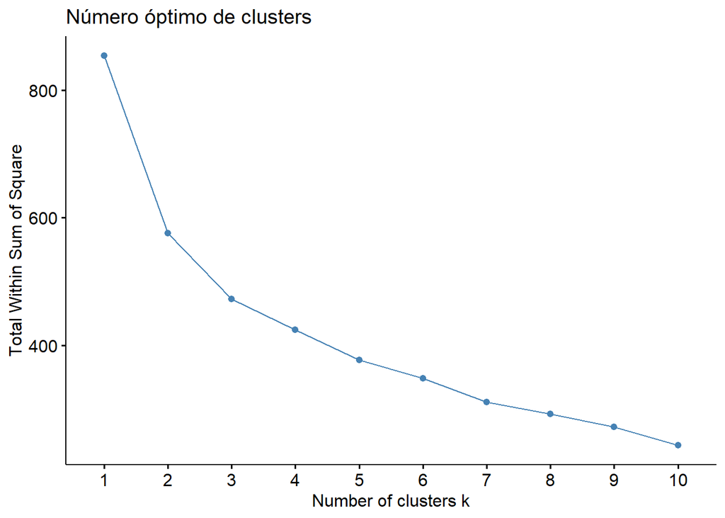

```r
library(factoextra)
library(NbClust)
fviz_nbclust(x = autismo.comp, FUNcluster = kmeans, method = "wss", k.max = 10) +
  labs(title = "Número óptimo de clusters")
```

El método Elbow calcula la varianza total intra-cluster en función del número de clusters y escoge como óptimo aquel valor a partir del cual añadir más clusters apenas consigue mejoría. En nuestro caso, no para de disminuir (y por tanto de mejorar) conforme aumentamos k, pudiendo desarrollar problemas de sobreajuste del modelo. No podemos tomar una decisión en base a este índice.

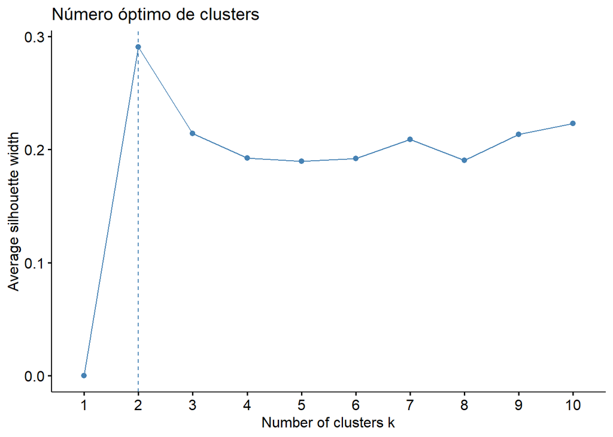

```r
library(factoextra)
library(NbClust)
fviz_nbclust(x = autismo.comp, FUNcluster = kmeans, method = "silhouette", k.max = 10) +
  labs(title = "Número óptimo de clusters")
```

El método de average silhouette considera como número óptimo de clusters aquel que maximiza la media del silhouette coeficient de todas las observaciones, en este caso 2.

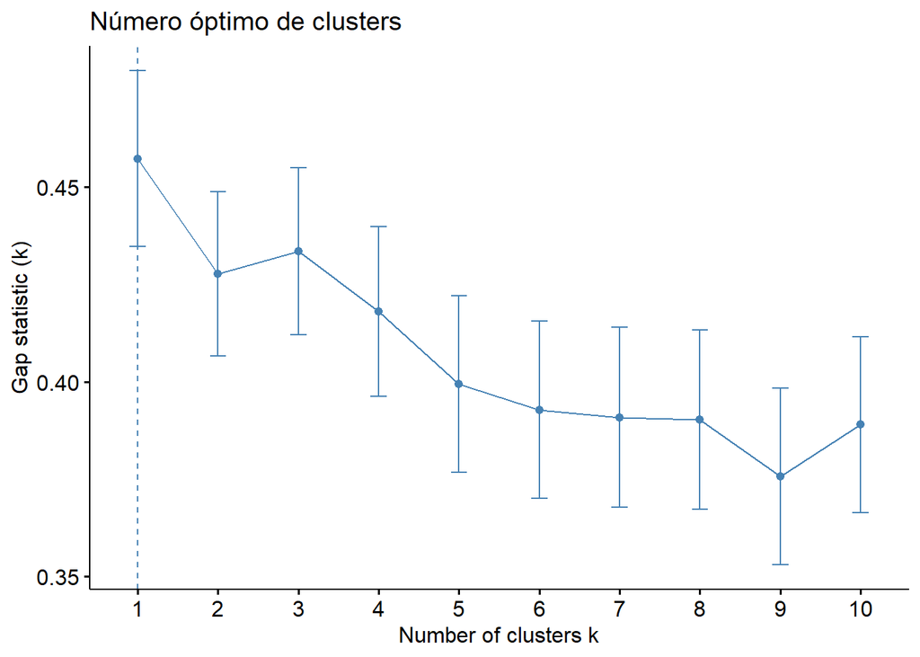

```r
library(factoextra)
set.seed(896)
library(NbClust)
fviz_nbclust(x = autismo.comp, FUNcluster = kmeans, method = "gap_stat", nboot = 500,
             k.max = 10, verbose = FALSE, nstart = 25) +
  labs(title = "Número óptimo de clusters")
```

El estadístico gap compara, para diferentes valores de k, la varianza total intra-cluster observada frente al valor esperado acorde a una distribución uniforme de referencia. En este caso, el estadistico gap nos indica que agrupar los individuos en un solo cluster nos aleja de una distribución uniforme aleatoria.

Estos 3 estadisticos no tiene por que coincidir y por esa razon resulta óptimo, realizar todos antes de tomar una decisión, de hecho es posible calcular todos los índices de la función NbClust() del paquete NbClust. Esta incorpora 30 índices distintos, dando la posibilidad de calcularlos todos en un único paso.

```r
library(factoextra)
install.packages("NbClust")
library(NbClust)
numero_clusters <- NbClust(data = autismo.comp, distance = "euclidean", min.nc = 2,
                           max.nc = 10, method = "kmeans", index = "alllong")
```

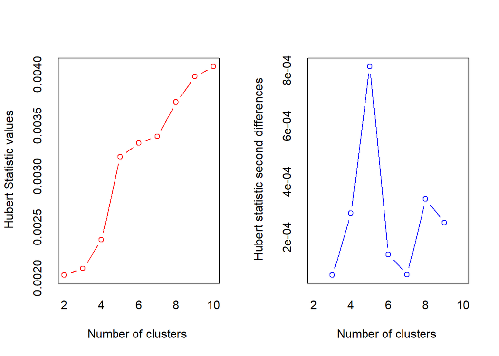

```
## *** : The Hubert index is a graphical method of determining the number of clusters.
##                 In the plot of Hubert index, we seek a significant knee that corresponds to a
##                 significant increase of the value of the measure i.e the significant peak in Hubert
##                 index second differences plot.
##
```

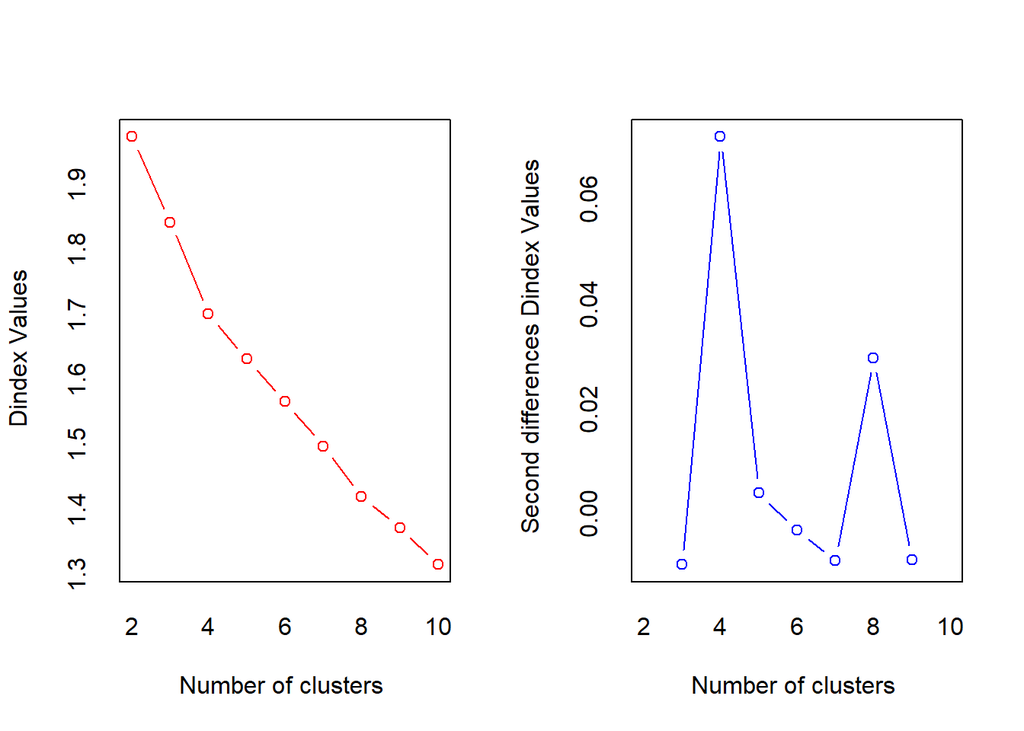

```
## *** : The D index is a graphical method of determining the number of clusters.
##                 In the plot of D index, we seek a significant knee (the significant peak in Dindex
##                 second differences plot) that corresponds to a significant increase of the value of
##                 the measure.
##
## * Among all indices:
## * 10 proposed 2 as the best number of clusters
## * 2 proposed 3 as the best number of clusters
## * 7 proposed 4 as the best number of clusters
## * 3 proposed 5 as the best number of clusters
## * 1 proposed 7 as the best number of clusters
## * 1 proposed 8 as the best number of clusters
## * 1 proposed 9 as the best number of clusters
## * 3 proposed 10 as the best number of clusters
##
##                    ***** Conclusion *****
##
## * According to the majority rule, the best number of clusters is  2
##
##
```

Teniendo en cuenta el algoritmo k-means y el resumen de estos indices el número optimo de clusters será 2, aunque se maximiza la varianza total intra-cluster y tiene un % de variabilidad explicada menor que k=3 o k=4.

**Estudio de la calidad/significancia de los clusters generados.**

Una vez seleccionado el número adecuado de clusters y aplicado el algoritmo de clustering pertinente se tiene que evaluar la calidad de los de los mismos, de lo contrario, podrían derivarse conclusiones de agrupación que no se corresponden con la realidad.

Silhouette width

```
##   cluster size ave.sil.width
## 1       1   46          0.34
## 2       2   78          0.26
```

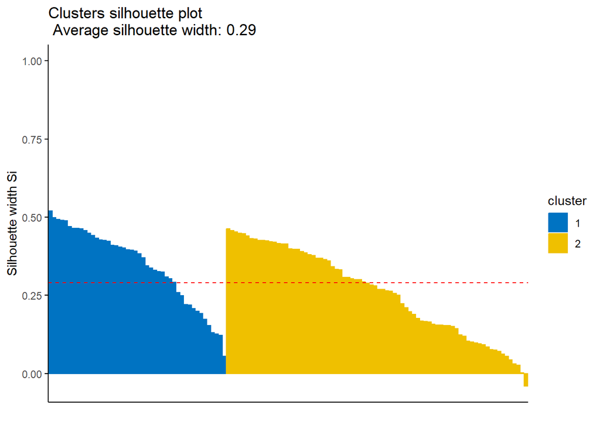

```r
library(factoextra)
km_clusters <- eclust(x = autismo.comp, FUNcluster = "kmeans", k = 2, seed = 123,
                      hc_metric = "euclidean", nstart = 25, graph = FALSE)
fviz_silhouette(sil.obj = km_clusters, print.summary = TRUE, palette = "jco",
                ggtheme = theme_classic())
```

```
##   cluster size ave.sil.width
## 1       1   39          0.28
## 2       2   38          0.19
## 3       3   47          0.20
```

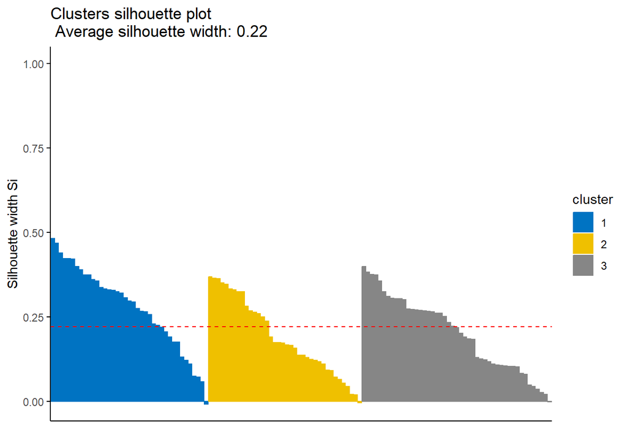

```r
library(factoextra)
km_clusters2 <- eclust(x = autismo.comp, FUNcluster = "kmeans", k = 3, seed = 123,
                      hc_metric = "euclidean", nstart = 25, graph = FALSE)
fviz_silhouette(sil.obj = km_clusters2, print.summary = TRUE, palette = "jco",
                ggtheme = theme_classic())
```

Cuantifica cómo de buena es la asignación que se ha hecho de una observación comparando su similitud con el resto de observaciones del mismo cluster frente a las de los otros clusters. Dibuja los cluster por orden de cercanía y si el valor medio está entre 0.5 y 0.7 es una clasificación asumible y será muy buena si está en torno a 1. En nuestro es bastante mala la clasificación, valor de 0.29 y tendrá valores similares para k=3 y k=4.

El algoritmo k-means presenta problemas de robustez frente a outliers. La única solución es excluirlos o recurrir a otros métodos de clustering más robustos como K-medoids (PAM).

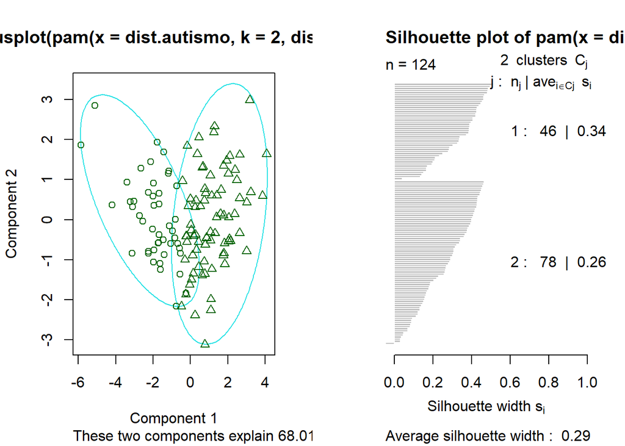

```r
library("cluster")
kmed <- pam(dist.autismo, k=2, diss=T)
par(mfrow=c(1,2))
plot(kmed,which.plots=1)
plot(kmed)
```

En este caso, volvemos a encontrarnos con una medida de clasificación no satisfactoria, por lo que concluiremos que nuestro conjunto de datos no presenta clusters definidos como perfiles genéticos bien diferenciados.

**C.Se sugiere obtener la media, mínimo y máximo de las variables para cada conglomerado y comenta los resultados.**

Estadisticos descriptivos para cluster 1

```r
summary(datos.autismo[km$cluster==1,])
```

```
##   x.205486_at     x.234972_at     x.212848_s_at    x.232674_at
##  Min.   :143.4   Min.   : 85.65   Min.   :34.65   Min.   :17.40
##  1st Qu.:163.4   1st Qu.:120.99   1st Qu.:44.15   1st Qu.:21.93
##  Median :186.5   Median :134.21   Median :51.00   Median :23.99
##  Mean   :183.9   Mean   :132.01   Mean   :50.39   Mean   :24.40
##  3rd Qu.:201.8   3rd Qu.:145.98   3rd Qu.:55.75   3rd Qu.:26.72
##  Max.   :242.1   Max.   :164.36   Max.   :69.83   Max.   :32.66
##   x.235889_at     x.1553235_at    x.244494_at     x.233835_at
##  Min.   :16.52   Min.   :18.44   Min.   :12.21   Min.   :13.10
##  1st Qu.:21.34   1st Qu.:23.95   1st Qu.:13.65   1st Qu.:15.58
##  Median :23.76   Median :27.71   Median :15.93   Median :17.45
##  Mean   :25.18   Mean   :26.23   Mean   :16.25   Mean   :17.57
##  3rd Qu.:26.54   3rd Qu.:28.67   3rd Qu.:17.52   3rd Qu.:19.90
##  Max.   :45.84   Max.   :31.93   Max.   :21.84   Max.   :23.52
##   x.242767_at      x.1552734_at     x.242980_at         factor
##  Min.   : 8.564   Min.   : 8.475   Min.   : 6.810   Autism : 8
##  1st Qu.:11.579   1st Qu.:11.137   1st Qu.: 7.742   Control:31
##  Median :12.214   Median :12.770   Median : 8.401
##  Mean   :12.590   Mean   :13.000   Mean   : 8.470
##  3rd Qu.:13.604   3rd Qu.:14.423   3rd Qu.: 9.052
##  Max.   :17.122   Max.   :20.280   Max.   :10.782
```

Estadisticos descriptivos para cluster 2

```r
summary(datos.autismo[km$cluster==2,])
```

```
##   x.205486_at     x.234972_at     x.212848_s_at    x.232674_at
##  Min.   :117.4   Min.   : 86.49   Min.   :36.56   Min.   :27.07
##  1st Qu.:139.5   1st Qu.:115.91   1st Qu.:51.71   1st Qu.:31.42
##  Median :151.1   Median :135.96   Median :58.04   Median :34.70
##  Mean   :150.8   Mean   :133.85   Mean   :56.88   Mean   :34.72
##  3rd Qu.:161.6   3rd Qu.:151.68   3rd Qu.:62.87   3rd Qu.:37.14
##  Max.   :198.0   Max.   :180.59   Max.   :74.46   Max.   :45.66
##   x.235889_at     x.1553235_at    x.244494_at     x.233835_at
##  Min.   :11.40   Min.   :22.86   Min.   :16.17   Min.   :16.93
##  1st Qu.:17.02   1st Qu.:28.10   1st Qu.:20.38   1st Qu.:20.85
##  Median :19.50   Median :30.39   Median :23.38   Median :22.28
##  Mean   :19.36   Mean   :31.20   Mean   :22.91   Mean   :22.81
##  3rd Qu.:21.96   3rd Qu.:34.00   3rd Qu.:25.10   3rd Qu.:24.41
##  Max.   :25.78   Max.   :40.47   Max.   :30.65   Max.   :27.70
##   x.242767_at     x.1552734_at     x.242980_at         factor
##  Min.   :10.28   Min.   : 7.424   Min.   : 7.601   Autism :30
##  1st Qu.:12.42   1st Qu.: 9.576   1st Qu.: 8.954   Control: 8
##  Median :14.35   Median :10.606   Median : 9.827
##  Mean   :14.74   Mean   :10.728   Mean   :10.072
##  3rd Qu.:16.06   3rd Qu.:11.244   3rd Qu.:11.076
##  Max.   :21.37   Max.   :16.874   Max.   :14.485
```

Estadisticos descriptivos para cluster 3

```r
summary(datos.autismo[km$cluster==3,])
```

```
##   x.205486_at     x.234972_at    x.212848_s_at    x.232674_at
##  Min.   :108.8   Min.   :112.4   Min.   :41.16   Min.   :17.38
##  1st Qu.:137.2   1st Qu.:140.7   1st Qu.:53.80   1st Qu.:26.42
##  Median :149.0   Median :156.7   Median :57.93   Median :28.73
##  Mean   :150.1   Mean   :158.0   Mean   :58.29   Mean   :29.05
##  3rd Qu.:167.3   3rd Qu.:177.9   3rd Qu.:63.01   3rd Qu.:32.63
##  Max.   :190.6   Max.   :208.7   Max.   :79.40   Max.   :36.97
##   x.235889_at     x.1553235_at    x.244494_at     x.233835_at
##  Min.   :12.71   Min.   :17.60   Min.   :13.88   Min.   :15.36
##  1st Qu.:17.66   1st Qu.:25.13   1st Qu.:17.11   1st Qu.:18.54
##  Median :20.70   Median :27.85   Median :18.94   Median :20.71
##  Mean   :21.21   Mean   :27.93   Mean   :18.79   Mean   :20.75
##  3rd Qu.:22.96   3rd Qu.:29.85   3rd Qu.:20.78   3rd Qu.:22.82
##  Max.   :34.55   Max.   :37.06   Max.   :23.08   Max.   :26.35
##   x.242767_at      x.1552734_at     x.242980_at         factor
##  Min.   : 9.151   Min.   : 7.430   Min.   : 6.616   Autism :27
##  1st Qu.:11.947   1st Qu.: 9.955   1st Qu.: 7.816   Control:20
##  Median :13.065   Median :10.612   Median : 8.801
##  Mean   :13.035   Mean   :10.613   Mean   : 8.734
##  3rd Qu.:14.130   3rd Qu.:11.237   3rd Qu.: 9.220
##  Max.   :18.164   Max.   :13.513   Max.   :12.130
```

Por último y a modo de curiosidad, veamos si ha tenido sentido realizar clustering comparando nuestros datos con una simulacion de datos aleatorios y el metodo hopkins. Es decir, veamos el **estudio de la tendencia de clustering**

```r
library(purrr)
datos.autismo_nofactor <- datos.autismo[,-12]
datos_simulados <- map_df(datos.autismo_nofactor,
                          .f = function(x){runif(n = length(x),
                                                 min = min(x),
                                                 max = max(x))
                            }
                          )

datos.autismo_nofactor <-  scale(datos.autismo_nofactor)
datos_simulados <- scale(datos_simulados)
```

```r
library(hopkins)
set.seed(123)
# Estadístico H para el set de datos autismo
hopkins(as.matrix(datos.autismo_nofactor))
```

```
## [1] 0.9982404
```

```r
# Estadístico H para el set de datos simulado
hopkins(as.matrix(datos_simulados))
```

```
## [1] 0.2491328
```

Concluimos por tanto, que nuestros datos si que tienen tendencia a agruparse con un valor en torno a 1 (valor satisfactorio en el test hopkins) pero los grupos no son de calidad y no estan bien diferenciados según nos indican los análisis realizados.